# R Training

# 9 Vectors

#### Learning goals

- Learn the various structures of data in `R`
- How to work with vectors in `R`

Data belong to different *classes*, as explained in the previous module, and they can be arranged into various **structures**.

So far we have been dealing only with variables that contain a single value, but the real value of `R` comes from assigning *entire sets* of data to a variable.

The simplest data structure in `R` is a **vector**. A vector is simply a set of values. A vector can contain only a single value, as we have been working with thus far, or it can contain many millions of values.

## Declaring and using vectors

To build up a vector in `R`, use the function `c()`, which is short for “concatenate”.

```r
x <- c(5,6,7,8)
x
[1] 5 6 7 8
```

Whenever you use the `c()` function, you are telling `R`: ‘Hey, get ready. I’m about to give you more than one value at once.’. Cough Cough.

You can use the `c()` function to concatenate two vectors together:

```r
x <- c(5,6,7,8)
y <- c(9,10,11,12)
z <- c(x,y)
z
[1]  5  6  7  8  9 10 11 12
```

You can also use `c()` to add values to a vector:

```r
x <- c(5,6,7,8)
x <- c(x,9)
x
[1] 5 6 7 8 9
```

You can also put vectors through logical tests:

```r
x <- c(1,2,3,4,5)
4 == x
[1] FALSE FALSE FALSE  TRUE FALSE
```

This command is asking `R` to tell you whether each element in `x` is equal to `4`.

You can create vectors of any data class (i.e., data type).

```r
x <- c("Greta","Nika","Crispin")
x
[1] "Greta"   "Nika"    "Crispin"
```

```r
y <- c(TRUE,TRUE,FALSE)
y
[1]  TRUE  TRUE FALSE
```

Note that all values within a vector *must* be of the same class. You can’t combine numerics and characters into the same vector. If you did, `R` would try to convert the numbers to characters. For example:

```r
x <- 4
y <- "6"
z <- c(x,y)
z
[1] "4" "6"
```

## Math with two vectors

When two vectors are of the same length, you can do arithmetic with them:

```r
x <- c(5,6,7,8)
y <- c(9,10,11,12)
x + y
[1] 14 16 18 20
```

```r
x - y
[1] -4 -4 -4 -4
```

```r
x * y
[1] 45 60 77 96
```

```r
x / y
[1] 0.5555556 0.6000000 0.6363636 0.6666667
```

**What happens when two vectors are *not* the same length?**

Well, it depends. If one vector is length 1 (i.e., a single number), then things usually work out well.

```r
x <- 5
y <- c(1,2,3,4,5,6,7,8,10)
x + y
[1]  6  7  8  9 10 11 12 13 15
```

In this command, the single element of `x` gets added to each element of `y`.

Another example, which you already saw above:

```r
a <- c(1,2,3,4,5)
b <- 4
a == b
[1] FALSE FALSE FALSE  TRUE FALSE
```

In this command, the single element of `b` gets compared to each element of `a`.

However, when both vectors contain multiple values but are not the same length, **be warned**: wonky things can happen. This is because `R` will start recycling the shorter vector:

```r
a <- c(1,2,3,4,5)
b <- c(3,4)
a + b
[1] 4 6 6 8 8
```

## Functions for handling vectors

We are about to list a bunch of core functions for working with vectors. Think of this like a toolbag. Each tool has a specific purpose and limited value: you can’t quite build a house with just a hammer. But when you learn how to use all of the tools in your tool bag *together*, you can build almost anything. But you have to know how to use each tool individually first.

**`length()`** tells you the number of elements in a vector:

```r
x <- c(5,6)
length(x)
[1] 2
```

```r
y <- c(9,10,11,12)
length(y)
[1] 4
```

The **colon symbol `:`** creates a vector with every integer occurring between a min and max:

```r
x <- 1:10
x
 [1]  1  2  3  4  5  6  7  8  9 10
```

**`seq()`** allows you to build a vector using evenly spaced *sequence* of values between a min and max:

```r
seq(0,100,length=11)
 [1]   0  10  20  30  40  50  60  70  80  90 100
```

In this command, you are telling `R` to give you a sequence of values from `0` to `100`, and you want the length of that vector to be `11`. `R` then figures out the spacing required between each value in order to make that happen.

Alternatively, you can prescribe the interval between values instead of the length:

```r
seq(0,100,by=7)
 [1]  0  7 14 21 28 35 42 49 56 63 70 77 84 91 98
```

**`rep()`** allows you to repeat a single value a specified number of times:

```r
rep("Hey!",times=5)
[1] "Hey!" "Hey!" "Hey!" "Hey!" "Hey!"
```

You can also use `rep()` to repeat each element of a vector a set number of times:

```r
rep(c("Hey!","Wohoo!"),each=3)
[1] "Hey!"   "Hey!"   "Hey!"   "Wohoo!" "Wohoo!" "Wohoo!"
```

**`head()`** and **`tail()`** can be used to retrieve the first 6 or last 6 elements in a vector, respectively.

```r
x <- 1:1000
head(x)
[1] 1 2 3 4 5 6
tail(x)
[1]  995  996  997  998  999 1000
```

You can also adjust how many elements to return:

```r
head(x,2)
[1] 1 2
tail(x,10)
 [1]  991  992  993  994  995  996  997  998  999 1000
```

**`sort()`** allows you to order a vector from its smallest value to its largest:

```r
x <- c(4,8,1,6,9,2,7,5,3)
sort(x)
[1] 1 2 3 4 5 6 7 8 9
```

**`rev()`** lets you reverse the order of elements within a vector:

```r
x <- c(4,8,1,6,9,2,7,5,3)
rev(x)
[1] 3 5 7 2 9 6 1 8 4
```

```r
rev(sort(x))
[1] 9 8 7 6 5 4 3 2 1
```

**`min()`** and **`max()`** lets you find the smallest and largest value in a vector.

```r
min(x)
[1] 1
```

```r
max(x)
[1] 9
```

**`which()`** allows you to ask, “For which elements of a vector is the following statement true?”

```r
x <- 1:10
which(x==4)
[1] 4
```

If no values within the vector meet the condition, a vector of length zero will be returned:

```r
x <- 1:10
which(x == 11)
integer(0)
```

**`which.min()`** and **`which.max()`** tells you which element is the smallest and largest in the vector, respectively:

```r
which.min(x)
[1] 1
```

```r
which.max(x)
[1] 10
```

**`%in%`** is a handy operator that allows you to ask whether a value occurs *within* a vector:

```r
x <- 1:10
4 %in% x
[1] TRUE
```

```r
11 %in% x
[1] FALSE
```

**`is.na()`** is a way of asking whether a vector contains missing, broken, or erroneous values. In `R`, such values are referred to using the phrase `NA`. When you see `NA`, think of `R` telling you, *‘Nah ah! Nope! Not Available!’*

```r
x <- c(3,5,7,NA,9,4)
is.na(x)
[1] FALSE FALSE FALSE  TRUE FALSE FALSE
```

This function is stepping through each element in the vector `x` and telling you whether that element is `NA`.

## Subsetting vectors

Since you will eventually be working with vectors that contain thousands of data points, it will be useful to have some tools for *subsetting* them – that is, looking at only a few select elements at a time.

You can subset a vector using square brackets `[ ]`. Whenever you use you use brackets, you are telling `R`: ‘Hey, I want some numbers, but *not everything*: just certain ones.’

```r
x <- 50:100
x[10]
[1] 59
```

This command is asking `R` to return the 10th element in the vector `x`.

```r
x[10:20]
 [1] 59 60 61 62 63 64 65 66 67 68 69
```

This command is asking `R` to return elements `10:20` in the vector `x`.

[output not shown]

[output not shown]

#### Exercises

**Creating sequences of numbers**

1. Use the colon symbol to create a vector of length 5 between a minimum and a maximum value of your choosing.
2. Create a second vector of length 5 using the `seq()` function. Use code to confirm that the length of this vector is 5.
3. Create a third vector of length 5 using the `rep()` function. Use code to confirm that the length of this vector is 5.
4. Finally, concatenate the three vectors and check that the length equals 15.

**Basic vector math**

5. Create a variable `x` that is a list of numbers of any size. Create a variable `y` of the same length.
6. Check to see if each values of `x` is greater than each value of y.
7. Check to see if the smallest value of `x` is greater than or equal to the average value of `y`.

**Vectors and object classes**

8. Create a vector with at least one number, then a second vector with at least one character string, then a third vector with at least one logical value. Identify the class of all three vectors.
9. Now concatenate these three vectors into a fourth vector. Identify the class of this fourth vector.

**Heads & tails**

10. Create a vector with at least 15 values.
11. Show the first six values of that vector using the `head()` function.
12. Figure out how to show the same result without a function, but instead with your new vector subsetting skills. Now replicate the `tail()` function, using those same skills. You may need to call the `length()` function as well.

**Shoe sizes**

13. Create a vector called `shoes`, which contains the shoe sizes of five people sitting near you. Use comments to keep track of which size is whose.
14. Arrange this set of shoe sizes in ascending order.
15. Arrange this set of shoe sizes in descending order.
16. Use code to find the the two largest shoe sizes in your vector. Don’t use subsetting; instead, write a line of code that would work even if more shoes were added to your vector.
17. What is the shoe size is closest to the mean of these shoe sizes?
18. Use the `which()` function to figure out which of your five neighbors this shoe size belongs to.

**Swimming timelines**

19. Now create a new vector called `swim_days`, which contains the number of days since those same five people last went swimming (in any body of water; estimating the days since is fine).
20. Use code to ask whether anyone went swimming less than five days ago.
21. Which of your neighbors, if any, went swimming in the last month?
22. Which of your neighbors, if any, have not been swimming the last month?
23. On average, how long has it been since these people have gone swimming?

**Dealing with `NA`s**

24. Create a vector named `x` with these values: `c(4,7,1,NA,9,2,8)`.
25. Use a function to decide whether or not each element of `x` is `NA`.
26. Use another function to find out which element in `x` is `NA`.
27. Write code that will subset `x` only to those values that are `NA`.
28. Write code that will subset `x` only to those values that are *not* `NA`.

**Sleep deficits**

29. Now create a vector called `sleep_time` with the number of hours you slept for each day in the last week.
30. Check if you slept more on day 3 than day 7.
31. Get the total number of hours slept in the last week.
32. Get the average number of hours slept in the last week.
33. Check if the total number of hours in the first 3 days is less than the total number of hours in the last 4 days.
34. Now create an object named `over_under`. This should be the difference between how much you slept each night and 8 hours (ie, 1.5 means you slept 9.5 hours and -2 means you slept 8 hours).
35. Write code to use `over_under` to calculate your sleep deficit / surplus this week (ie, the total hours over/under the amount of sleep you would have gotten had you slept 8 hours every night).
36. Write code to get the minimum number of hours you slept this week.
37. Write code to calculate how many hours of sleep you would have gotten had you sleep the minimum number of hours every night.
38. Write code to calculate the average of the hours of sleep you got on the 3rd through 6th days of the week.
39. Write code to calculate how many hours of sleep you would get in a year if you were to sleep the same amount every night as the average amount you slept from the 3rd to 6th days of the week.
40. Write code to calculate how many hours of sleep per year someone who sleeps 8 hours a night gets.
41. How many hours more/less than the 8 hours per night sleeper do you get in a year, assuming you sleep every night the average of the amount you slept on the first and last day of this week?
42. What is your total sleep deficit for the last week?
43. How many more hours per night, on average, do you need to sleep for the rest of the month so that, by the end of the month, you have a sleep deficit of zero?

# 10 Calling functions

#### Learning goals

- Understand what functions are, and why they are awesome
- Understand how functions work
- Understand how to read function documentation

You have already worked with many `R` functions; commands like `getwd()`, `length()`, and `unique()` are all functions. You know a command is a function because it has parentheses, `()`, attached at its end.

Just as **variables** are convenient names used for calling *objects* such as vectors or dataframes, **functions** are convenient names for calling *processes* or *actions*. An `R` function is just a batch of code that performs a certain action.

Variables represent data, while functions represent code.

Most functions have three key components: (1) one or more inputs, (2) a process that is applied to those inputs, and (3) an output of the result. When you call a function in `R`, you are saying, “Hey `R`, take this information, do something to it, and return the result to me.” You supply the function with the inputs, and the function takes care of the rest.

Take the function `mean()`, for example. `mean()` finds the arithmetic mean (i.e., the average) of a set of values.

```r
x <- c(4,6,3,2,6,8,5,3) # create a vector of numbers
mean(x) # find their mean
[1] 4.625
```

In this command, you are feeding the function `mean()` with the input `x`.

Perhaps this analogy will help: When you think of functions, think of vending machines: you give a vending machine two inputs – your money and your snack selection – then it checks to see if your selection of choice is in stock, and if the money you provided is enough to pay for the snack you want. If so, the machine returns one output (the snack).

### Base functions in `R`

There are hundreds of functions already built-in to `R`. These functions are called *“base functions”*. Throughout these modules, we have been – and will continue – introducing you to the most commonly used base functions.

You can access other functions through bundles of external code known as *packages*, which we explain in an upcoming module.

You can also write your *own* functions (and you will!). We provide an entire module on how to do this.

Note that not all functions require an input. The function `getwd()`, for example, does not need anything in its parentheses to find and return current your working directory.

### Saving function output

You will almost always want to save the result of a function in a new variable. Otherwise the function just prints its result to the *Console* and `R` forgets about it.

You can store a function result the same way you store any value:

```r
x <- c(4,6,3,2,6,8,5,3)
x_mean <- mean(x)
x_mean
[1] 4.625
```

### Functions with multiple inputs

Note that `mean()` accepts a second input that is called `na.rm`. This is short for `NA.remove`. When this is set to `TRUE`, `R` will remove broken or missing values from the vector before calculating the mean.

```r
x <- c(4,6,3,2,NA,8,5,3)  # note the NA
mean(x,na.rm=TRUE)
[1] 4.428571
```

Note that you provided the function `mean()` with two inputs, `x` and `na.rm`, and that you separated each input with a comma. This is how you pass multiple inputs to a function.

### Function defaults

```r
x <- c(4,6,3,2,NA,8,5,3)  # note the NA
mean(x)
[1] NA
```

Because `R` will assume you are using the default value for `na.rm`, which is `FALSE`, which means you do not want to remove missing values before trying to calculate the mean.

### Function documentation (i.e., getting help)

When you enter this command, the help documentation for `mean()` will appear in the bottom right pane of your `RStudio` window:

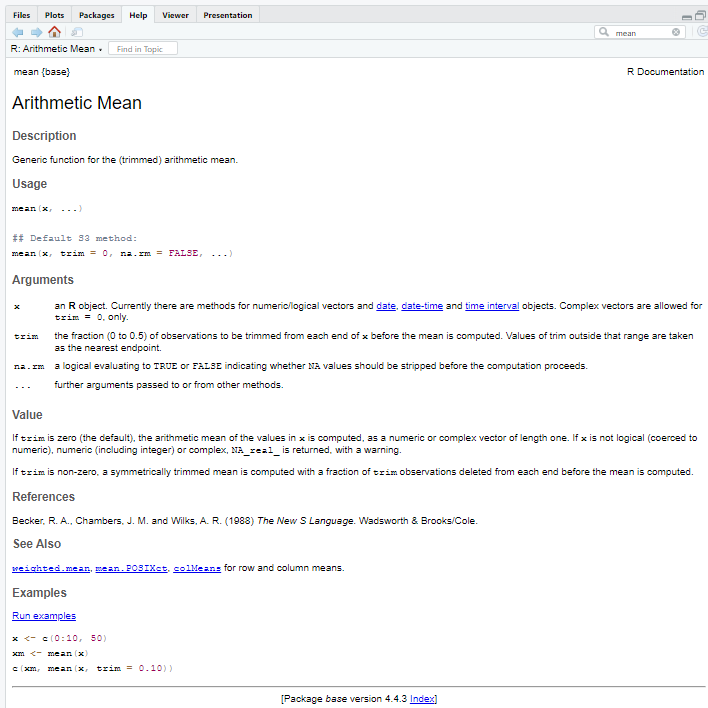

Learning how to read this documentation is essential to becoming competent in using `R`.

**Be warned:** not all documentation is easy to understand! You will come to really resent poorly written documentation and really appreciate well-written documentation; the few extra minutes taken by the function’s author to write good documentation saves users around the world hours of frustration and confusion.

- The `Title` and `Description` help you understand what this function does.
- The `Usage` section shows you how type out the function.
- The `Arguments` section lists out each possible argument (which in `R` lingo is another word for *input* or *parameter*), explains what that input is asking for, and details any formatting requirements.
- The `Value` section describes what the function returns as output.
- At the bottom of the help page, example code is provided to show you how the function works. You can copy and paste this code into your own script of *Console* and check out the results.

Note that more complex functions may also include a `Details` section in their documentation, which gives more explanation about what the function does, what kinds of inputs it requires, and what it returns.

### Function examples

`R` comes with a set of base functions for **descriptive statistics**, which provide good examples of how functions work and why they are valuable.

We can use the same vector as the input for all of these functions:

```r
x <- c(4,6,3,2,NA,8,9,5,6,1,9,2,6,3,0,3,2,5,3,3)  # note the NA
```

**`mean()`** has been explained above.

```r
result <- mean(x,na.rm=TRUE)
result
[1] 4.210526
```

**`median()`** returns the median value in the supplied vector:

```r
result <- median(x,na.rm=TRUE)
result
[1] 3
```

**`sd()`** returns the standard deviation of the supplied vector:

```r
result <- sd(x,na.rm=TRUE)
result
[1] 2.594416
```

**`summary()`** returns a vector that describes several aspects of the vector’s distribution:

```r
result <- summary(x,na.rm=TRUE)
result
   Min. 1st Qu.  Median    Mean 3rd Qu.    Max.    NA's
  0.000   2.500   3.000   4.211   6.000   9.000       1
```

#### Exercises

**Sock survey**  
You conducted a survey of your peers in this class, asking each of them how many pairs of socks they own. Most of your peers responded, but one person refused to tell you. Instead of giving you a number, they told you, “Nah!”.

Your results look like this:

```r
# People you asked
peers <- c('Keri','Eric','Joe','Ben','Matthew','Jim')

# Their responses
socks <- c(6,8,14,1,NA,4)
```

**1.** Calculate the average pairs of socks owned by your peers.

**2.** Calculate the total pairs of socks owned by cooperative students in this class.

**3.** Use code to find the name of the person who refused to tell you about their socks.

**4.** Use code to find the names of the people who were willing to cooperate with your survey.

**5.** Use code to find the name of the person with the most socks.

**6.** Use code to find the name of the person with the fewest socks.

**Age survey**

**7.** Create a vector named `years` with the years of birth of everyone in the room.

**8.** What is the average year of birth?

**9.** What is the median year of birth?

**10.** Create a vector called `ages` which is the (approximate) age of each person.

**11.** What is the minimum age?

**12.** What is the maximum age?

**13.** What is the median age?

**14.** What is the average age?

**15.** “Summarize” `ages`.

**16.** What is the range of ages?

**17.** What is the standard deviation of ages?

**18.** Look up help on the function `sort()`.

**19.** Created a vector called `sorted_ages`. It should be, well, sorted ages.

**20.** Look up the `length()` function.

**21.** How many people are the group?

**22.** Create an object called `old`. Assign to this object an age (such as 36) at which someone should be considered “old”.

**23.** Create an object called `old_people`. This should be a boolean/logical vector indicating if each person is old or not.

**24.** Is the seventh person in `ages` old?

**25.** How many years from being old or young is person 12?

**Rolling the dice**

**26.** Look up the help page for the function `sample()`.

Here’s an example of how this function works. This line of code will sample a single random number from the vector `1:10`.

```r
sample(1:10,size=1)
[1] 2
```

This command will draw three random samples:

```r
sample(1:10,size=3)
[1] 7 2 1
```

**27.** Use this function to simulate the rolling of a single die.

**28.** Now use this to simulate the rolling of a die 10 times. (*Note:* look at the `replace` input for `sample()`.)

**29.** Now use this to roll the die 10,000 times, and assign the result to a new variable. (*Note:* look at the `replace` input for `sample()`.)

**30.** Look up the help page for the function `table()`.

**31.** Use the `table()` function to ask whether the diel you rolled in question 29 is fair, or if it is weighted or biased toward a certain side. Can you describe what the `table()` function is doing?

**30.** Now use the `sample()` function to solve a different problem: your friends want to order take out from the Tavern, but no one in your group of 4 wants to be the one to go pick it up. Write code that will randomly select who has to go.

# 11 Subsetting & filtering

#### Learning goals

- Understand how to subset / filter data

You have been introduce to subsetting and filtering briefly in previous modules, but it is such an important concept that we want to devote an entire module to practicing it.

## Subsetting with indices

You have already learned that certain elements of a vector can be called by specifying an index:

```r
x <- 55:65

# Call x without subsetting
x
 [1] 55 56 57 58 59 60 61 62 63 64 65
```

```r
# Now call only the third element of x
x[3]
[1] 57
```

Remember: brackets indicate that you don’t want everything from a vector; you just want certain elements. ‘I want `x`, *but not all of it.*’

You can also subset an object by calling multiple indices:

```r
# Now call the third, fourth, and fifth element of x
x[c(3,4,5)]
[1] 57 58 59
```

```r
# Another way of doing the same thing:
x[3:5]
[1] 57 58 59
```

## Subsetting with booleans

You can also subset objects with ‘booleans’. This will eventually be your most common way of filtering data, by far.

Recall that boolean / logical data have two possible values: `TRUE` or `FALSE`. For example:

```r
# Store Joe's age
joes_age <- 35

# Set the cutoff for old age
old_age <- 36

# Ask whether Joe is old
joes_age >= old_age
[1] FALSE
```

Recall also that you can calculate whether a condition is `TRUE` or `FALSE` on multiple elements of a vector. For example:

```r
# Build a vector of multiple ages
ages <- c(10, 20, 30, 40, 50, 60)

# Set the cutoff for old age
old_age <- 36

# Ask which ages are considered old
ages >= old_age
[1] FALSE FALSE FALSE  TRUE  TRUE  TRUE
```

Boolean vectors are super useful for subsetting. Think of ‘subsetting’ as keeping only those elements of a vector for which a condition is `TRUE`.

```r
x <- 55:59

# Call x without subsetting
x
[1] 55 56 57 58 59
```

```r
# Now subset to the second, third, and fourth element
x[c(FALSE, TRUE, TRUE, TRUE, FALSE)]
[1] 56 57 58
```

That command returned elements for which the subetting vector was `TRUE`.

This is equivalent to…

```r
x[2:4]
[1] 56 57 58
```

You can also get the same result using a logical test, since logical tests return boolean values:

```r
# Develop your logical test: ask which values of x are in the vector 56:58
x %in% c(56,57,58)
[1] FALSE  TRUE  TRUE  TRUE FALSE

# Now plug taht test it into the subsetting brackets
x[ x %in% c(56,57,58) ]
[1] 56 57 58
```

This methods gets really useful when you are working with bigger datasets, such as this one:

```r
# Make a large dataset of random numbers
y <- sample(1:1000,size=100)
length(y)
[1] 100
```

```r
range(y)
[1]   9 999
```

With a dataset like this, you can use a boolean filter to figure out how many values are greater than, say, 90.

First, develop your logical test, which will tell you whether each value in the vector is greater than 90:

```r
# Develop your logical test,
y > 90
  [1]  TRUE  TRUE  TRUE  TRUE FALSE  TRUE  TRUE  TRUE  TRUE  TRUE  TRUE  TRUE
 [13]  TRUE  TRUE  TRUE  TRUE  TRUE  TRUE  TRUE  TRUE  TRUE  TRUE  TRUE  TRUE
 [25]  TRUE  TRUE  TRUE  TRUE FALSE  TRUE  TRUE  TRUE  TRUE  TRUE  TRUE FALSE
 [37]  TRUE  TRUE  TRUE  TRUE  TRUE  TRUE  TRUE  TRUE  TRUE  TRUE  TRUE  TRUE
 [49]  TRUE  TRUE  TRUE  TRUE  TRUE  TRUE FALSE  TRUE  TRUE  TRUE  TRUE  TRUE
 [61]  TRUE  TRUE FALSE  TRUE  TRUE  TRUE  TRUE  TRUE  TRUE  TRUE FALSE  TRUE
 [73] FALSE  TRUE  TRUE FALSE  TRUE  TRUE FALSE  TRUE  TRUE  TRUE  TRUE FALSE
 [85]  TRUE  TRUE  TRUE  TRUE  TRUE  TRUE  TRUE  TRUE  TRUE  TRUE  TRUE  TRUE
 [97]  TRUE  TRUE  TRUE  TRUE
```

Now, to get the values corresponding to each `TRUE` in this list, plug your logical test into your subsetting brackets.

```r
y[y > 90]
 [1] 592 645 565 760 231 820 529 330 942 832 229 205 994 564 904 804 959 744 513
[20] 802 232 195 110 143 929 541 701 782 834 562 396 843 215 625 376 325 499 237
[39] 407 495 646 423 628 429 463 899 932 420 947 966 803 561 713 696 298 875 489
[58] 789 584 242 458 537 173 549 641 697 829 953 595 413 509 708 374 935 109 311
[77] 982 909 136 402 745 999 508 289 990 338 145 261 503 627
```

Here’s another way you can do the same thing:

```r
# Save the result of your logical test in a new vector
verdicts <- y > 90

# Use that vector to subset y
y[verdicts]
 [1] 592 645 565 760 231 820 529 330 942 832 229 205 994 564 904 804 959 744 513
[20] 802 232 195 110 143 929 541 701 782 834 562 396 843 215 625 376 325 499 237
[39] 407 495 646 423 628 429 463 899 932 420 947 966 803 561 713 696 298 875 489
[58] 789 584 242 458 537 173 549 641 697 829 953 595 413 509 708 374 935 109 311
[77] 982 909 136 402 745 999 508 289 990 338 145 261 503 627
```

You can use double logical tests too. For example, what if you want all elements between the values 70 and 90?

```r
verdicts <- y > 70 & y < 90
y[verdicts]
[1] 84
```

### Review assignment

**1.** Create a vector named `nummies` of all numbers from 1 to 100

**2.** Create another vector named `little_nummies` which consists of all those numbers which are less than or equal to 30

**3.** Create a boolean vector named `these_are_big` which indicates whether each element of `nummies` is greater than or equal to 70

**4.** Use `these_are_big` to subset `nummies` into a vector named `big_nummies`

**5.** Create a new vector named `these_are_not_that_big` which indicates whether each element of `nummies` is greater than 30 and less than 70. You’ll need to use the `&` symbol.

**6.** Create a new vector named `meh_nummies` which consists of all `nummies` which are greater than 30 and less than 70.

**7.** How many numbers are greater than 30 and less than 70?

**8.** What is the sum of all those numbers in `meh_nummies`